# Course Project: Practical Machine Learning

Lukas Schwarzensteiner

23.10.2015

**Background**

Using devices such as Jawbone Up, Nike FuelBand, and Fitbit it is now possible to collect a large amount of data about personal activity relatively inexpensively. These type of devices are part of the quantified self movement – a group of enthusiasts who take measurements about themselves regularly to improve their health, to find patterns in their behavior, or because they are tech geeks. One thing that people regularly do is quantify how much of a particular activity they do, but they rarely quantify how well they do it. In this project, your goal will be to use data from accelerometers on the belt, forearm, arm, and dumbell of 6 participants. They were asked to perform barbell lifts correctly and incorrectly in 5 different ways. More information is available from the website here: http://groupware.les.inf.puc-rio.br/har (see the section on the Weight Lifting Exercise Dataset).

**Data**

The training data for this project are available here:

https://d396qusza40orc.cloudfront.net/predmachlearn/pml-training.csv

The test data are available here:

https://d396qusza40orc.cloudfront.net/predmachlearn/pml-testing.csv

The data for this project come from this source: http://groupware.les.inf.puc-rio.br/har. If you use the document you create for this class for any purpose please cite them as they have been very generous in allowing their data to be used for this kind of assignment.

**What you should submit**

The goal of your project is to predict the manner in which they did the exercise. This is the “classe” variable in the training set. You may use any of the other variables to predict with. You should create a report describing how you built your model, how you used cross validation, what you think the expected out of sample error is, and why you made the choices you did. You will also use your prediction model to predict 20 different test cases.

1. Your submission should consist of a link to a Github repo with your R markdown and compiled HTML file describing your analysis. Please constrain the text of the writeup to < 2000 words and the number of figures to be less than 5. It will make it easier for the graders if you submit a repo with a gh-pages branch so the HTML page can be viewed online (and you always want to make it easy on graders :-).
2. You should also apply your machine learning algorithm to the 20 test cases available in the test data above. Please submit your predictions in appropriate format to the programming assignment for automated grading. See the programming assignment for additional details.

### **Preparation of Data**

First the caret package is loaded which helps already in the data preparation phase tp preprocess the data. The traing and the testing datasets are loaded. Both have 160 variables, from which many contain only very few or none values. Those are getting eliminated in a first step.

```r
library(caret)
#read in the data from csv
training <- read.csv("pml-training.csv")
testing <- read.csv("pml-testing.csv")
#identify variables which are containing only very few values
nearzero <- nearZeroVar(training, saveMetrics = TRUE)
nearzero2 <- nearZeroVar(testing, saveMetrics = TRUE)
#remove those variables from the dataframes
training <- training[, !nearzero$nzv]
testing <- testing[, !nearzero2$nzv]
#training fata farme still has variables with only NAs, which are removed too
training <- training[,colSums(is.na(training)) == 0]
#remove non relevant variables (names, number, timestamps)
training <- training[, -c(1:5)]
testing <- testing[, -c(1:5)]
#test whether both dataframes have same columns in order to make sure predictions can be made at a later stage
sameNames <- colnames(training) == colnames(testing)
colnames(training)[sameNames==FALSE]
```

```
## [1] "classe"
```

```r
colnames(testing)[sameNames==FALSE]
```

```
## [1] "problem_id"
```

Now we have a training dataset with 54 variables from which one ist the “classe” variables, which shall be predicted. Apart from that we have testing dataset, with the same variables, but with a variable called “problem_id” instead of the “classe” variable.

For all models the options are set to equal levels (if the apply) beforehand.

In order to be able to reproduce the results a seed is set.

```r
set.seed(777)
SetTraincontrol <- trainControl(method = "cv", number = 6, verboseIter=FALSE , preProcOptions="pca", allowParallel=TRUE)
```

In terms of cross-validation the training dataset is split into 6 folds.

The train function uses again cross-validation to optimize the model hyperparameters.

### **Testing different Cluster Models**

Now three different methods will be used to train models from the training dataset.

```r
modelRp <- train(classe ~ ., method="rpart", data=training, trControl= SetTraincontrol)
modelRp
```

```
## CART
##
## 19622 samples
##    53 predictor
##     5 classes: 'A', 'B', 'C', 'D', 'E'
##
## No pre-processing
## Resampling: Cross-Validated (6 fold)
## Summary of sample sizes: 16352, 16352, 16352, 16351, 16351, 16352, ...
## Resampling results across tuning parameters:
##
##   cp          Accuracy   Kappa       Accuracy SD  Kappa SD
##   0.03891896  0.5542781  0.42947080  0.03771450   0.05318138
##   0.05998671  0.4064294  0.19254714  0.06245016   0.10552072
##   0.11515454  0.3378874  0.08147667  0.04148617   0.06314991
##
## Accuracy was used to select the optimal model using  the largest value.
## The final value used for the model was cp = 0.03891896.
```

```r
library(rattle)
```

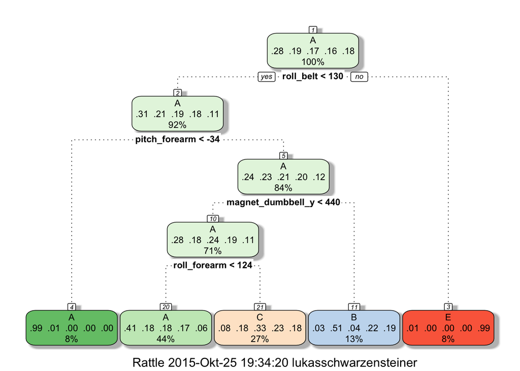

```r
fancyRpartPlot(modelRp$finalModel)
```

This model has an accuracy of 0.554.

**Random Forest**

The next model is a random forest model.

```r
library(randomForest)
modelRf <- randomForest(classe ~. , data=training, method="class", trControl= SetTraincontrol)
modelRf
```

```
##
## Call:
##  randomForest(formula = classe ~ ., data = training, method = "class",      trControl = SetTraincontrol)
##                Type of random forest: classification
##                      Number of trees: 500
## No. of variables tried at each split: 7
##
##         OOB estimate of  error rate: 0.14%
## Confusion matrix:
##      A    B    C    D    E class.error
## A 5580    0    0    0    0 0.000000000
## B    3 3793    1    0    0 0.001053463
## C    0    6 3416    0    0 0.001753361
## D    0    0   11 3204    1 0.003731343
## E    0    0    0    5 3602 0.001386194
```

The OOB estimate of error rate is 0.14%.

**Logit Boosted model**

The last model is a Logit Boosted model.

```r
modelLb <- train(classe ~ ., data = training, method = "LogitBoost", trControl= SetTraincontrol)
modelLb
```

```
## Boosted Logistic Regression
##
## 19622 samples
##    53 predictor
##     5 classes: 'A', 'B', 'C', 'D', 'E'
##
## No pre-processing
## Resampling: Cross-Validated (6 fold)
## Summary of sample sizes: 16352, 16351, 16352, 16352, 16351, 16352, ...
## Resampling results across tuning parameters:
##
##   nIter  Accuracy   Kappa      Accuracy SD  Kappa SD
##   11     0.8464682  0.8024190  0.010910256  0.014163127
##   21     0.9031904  0.8765746  0.011277159  0.014229454
##   31     0.9244282  0.9038188  0.006073336  0.007665679
##
## Accuracy was used to select the optimal model using  the largest value.
## The final value used for the model was nIter = 31.
```

This model has an accuracy of 0.9244, where 31 iterations have been needed to find that model.

### **Model selection, Out-of-Sample Error and Prediction**

According to accuracy values of the three different models the random forest model is choosen as the final model. The expected out-of-sample error is assumed to be 0.14%.

The random forest model is now applied on the testing dataset to predict the manner in which the members did the exercise.

```r
modelRf
```

```
##
## Call:
##  randomForest(formula = classe ~ ., data = training, method = "class",      trControl = SetTraincontrol)
##                Type of random forest: classification
##                      Number of trees: 500
## No. of variables tried at each split: 7
##
##         OOB estimate of  error rate: 0.14%
## Confusion matrix:
##      A    B    C    D    E class.error
## A 5580    0    0    0    0 0.000000000
## B    3 3793    1    0    0 0.001053463
## C    0    6 3416    0    0 0.001753361
## D    0    0   11 3204    1 0.003731343
## E    0    0    0    5 3602 0.001386194
```

```r
submission <- predict(modelRf, testing)
submission
```

```
##  1  2  3  4  5  6  7  8  9 10 11 12 13 14 15 16 17 18 19 20
##  B  A  B  A  A  E  D  B  A  A  B  C  B  A  E  E  A  B  B  B
## Levels: A B C D E
```

### **Submission of 20 test files**

With the given function one file for each of the 20 test predictions is created.

```r
pml_write_files = function(x){
  n = length(x)
  for(i in 1:n){
    filename = paste0("problem_id_",i,".txt")
    write.table(x[i],file=filename,quote=FALSE,row.names=FALSE,col.names=FALSE)
  }
}

pml_write_files(submission)
```